# Plotting

As plotting is an important part of graduate work, I will give a brief demonstration of how to make scientific plots using free software. You are welcome to use any software you please on your homework (MATLAB, Maple, Mathematica, and Microsoft Excel are all popular commercial tools that can generate good plots with some effort), but here I will use the free software, Python.

## Getting the software

Python is a full programming language used for many things outside of scientific plotting. To use Python for scientific plots, we must install certain libraries. A simple way to install all the appropriate libraries in any system (Windows, OS X, or Linux) is to install Anaconda: https://www.continuum.io/downloads You may download either the 2.x version (has a little more compatibility with older libraries) or the 3.x version (more future-proofed) for simple plotting, both versions will be indistinguishable. This will install Python along with all the libraries you will need, it is a relatively large installation and may include several things you do not need. Thus, if you are worried about installation space, you may also install only the bare necessities by installing miniconda: http://conda.pydata.org/miniconda.html If you have chosen the minimalistic (mini-conda) route, you should install these packages by typing

```
conda install numpy scipy matplotlib ipython
```

in the command line.

Optionally, you may also want to use the Spyder IDE to write your Python code in. If this is the case, you may install it using

```
conda install spyder
```

in the command line.

Another optonal library that can be installed modifies the default color schemes. You can install it using

```
conda install seaborn
```

## Initial setup

In Python we start by importing the libraries that we will need.

```python
import numpy as np
from matplotlib import pyplot as plt
#optional, for prettier default color scheme
import seaborn as sb
#make fonts bigger
sb.set(font_scale=1.5)
#only needed for "live notebooks" such as this demo
%matplotlib inline
```

Now we can initiate our variables and make a nice plot

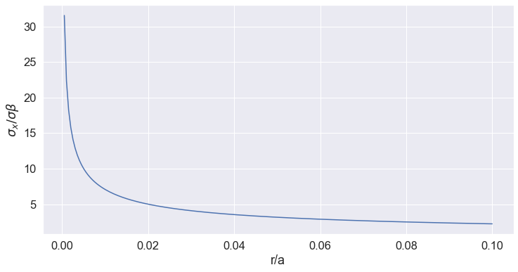

```python
ra = np.linspace(0,0.1,200)
fig = plt.figure(figsize=(12,6))
plt.plot(ra,1/np.sqrt(2*ra))
plt.xlabel('r/a')
plt.ylabel(r'$\sigma_x/\sigma \beta$')
```

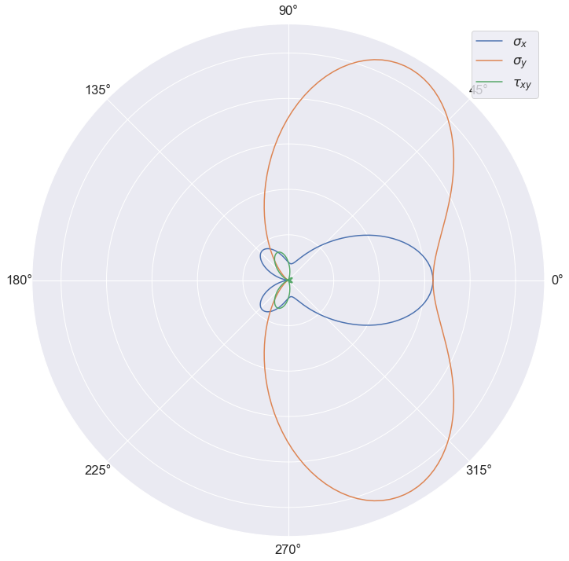

```python
t = np.linspace(0,2*np.pi,200)
fig = plt.figure(figsize=(12,12))
ax = plt.subplot(111,projection='polar')
ax.set_yticklabels([])
ax.plot(t,1/(2*np.pi)*np.cos(t/2)**2*(1-np.sin(t/2)*np.sin(3*t/2))**2, label=r'$\sigma_x$')
ax.plot(t,1/(2*np.pi)*np.cos(t/2)**2*(1+np.sin(t/2)*np.sin(3*t/2))**2, label=r'$\sigma_y$')
ax.plot(t,1/(2*np.pi)*(np.sin(t/2)*np.cos(t/2)*np.cos(3*t/2))**2, label=r'$\tau_{xy}$')
ax.legend(loc='best')
```

## Important plot features

Use a color scheme and pattern which allows the reader to clearly distinguish between the different lines being plotted.

Label axes clearly, if units are used they should be included in the axis label.

In research papers, you will often omit the plot title, opting instead for a more descriptive caption. For homework assignements you may use either.